# DTW_PCA

Katharina Hellmund & Nadia Hajighassem

2023-12-29

# 1 DTW on PCA

## 1.1 Importing components

```r
# Directory where the components are stored
components_dir <- "results/PCA"

                  #IMPORTING ALL COMPONENTS FROM A#
# List all CSV files in the directory that include "_A" in their names
component_files_A <- fs::dir_ls(path = components_dir, glob = "*_A.csv")

component_list_A <- list()

# Loop through each CSV file, read it into a dataframe, and store it in the list with its original file name
for (csv_file in component_files_A) {
  # Extract the file name without the extension
  file_name <- tools::file_path_sans_ext(basename(csv_file))

  # Read the CSV file into a dataframe and assign it to the list with the file name as the list name
  component_list_A[[file_name]] <- read.csv(csv_file)
}

                  #IMPORTING ALL COMPONENTS FROM B#
# List all CSV files in the directory that include "_B" in their names
component_files_B <- fs::dir_ls(path = components_dir, glob = "*_B.csv")

component_list_B <- list()

# Loop through each CSV file, read it into a dataframe, and store it in the list with its original file name
for (csv_file in component_files_B) {
  # Extract the file name without the extension
  file_name <- tools::file_path_sans_ext(basename(csv_file))

  # Read the CSV file into a dataframe and assign it to the list with the file name as the list name
  component_list_B[[file_name]] <- read.csv(csv_file)
}

#IMPORTING COMPONENT WEIGHTS#
PCA_component_weights <- read_csv("results/PCAcomponentweights.csv")
```

## 1.2 DTW Scoring each pair (Two components)

In creating the PCA, we also made screeplots to see how much of the data was described by each component. As so, it would not be reflective of the data if both components were weighted equally. Therefore, the weights that were defined previously have been imported, and will be used to assign a weight to each component. For the remainder of what is not explained by either component 1 or 2, the second component will inherit the weight from component 3,4,5 etc.

This means, that if component number 1 explains 70% of the data, the DTW score will be multiplied by 0.7. Component 2 will then count for the remainder (1-0.7) even if it only counts for 25%. This is done in order to spare computational power, and in most cases, two components count for >90% of data,

First we find the DTW for each pair:

```r
# Load the dtw library
library(dtw)

# Initialize a dataframe to store the results
dtw_results_df_combined <- data.frame(DF_Name = character(0), # Add a column for dataframe names
                                      DTW_Component_1 = numeric(0),
                                      DTW_Component_2 = numeric(0))

# Retrieve the names of the dataframes in component_list_A
df_names <- names(component_list_A)

# Loop through each index in the component lists
for (i in seq_along(component_list_A)) {
    # Select the i-th dataframe from each list
    component_A_df <- component_list_A[[i]]
    component_B_df <- component_list_B[[i]]

    # Extract the first PCA component from each dataframe
    component_A_1 <- component_A_df[, 1] # Assuming the first column is the first PCA component
    component_B_1 <- component_B_df[, 1] # Same assumption for component_list_B

    # Calculate DTW distance for the first PCA component
    dtw_distance_1 <- dtw(component_A_1, component_B_1, keep = TRUE)$distance

    # Extract the second PCA component from each dataframe
    component_A_2 <- component_A_df[, 2] # Assuming the second column is the second PCA component
    component_B_2 <- component_B_df[, 2] # Same assumption for component_list_B

    # Calculate DTW distance for the second PCA component
    dtw_distance_2 <- dtw(component_A_2, component_B_2, keep = TRUE)$distance

    # Add the results to the dataframe
    dtw_results_df_combined <- rbind(dtw_results_df_combined,
                                     data.frame(DF_Name = df_names[i], # Use the dataframe name
                                                DTW_Component_1 = dtw_distance_1,
                                                DTW_Component_2 = dtw_distance_2))
}

# Print and view the dataframe
print(dtw_results_df_combined)
```

```
##                DF_Name DTW_Component_1 DTW_Component_2
## 1   group0_jointlead_A       3139.9834        9146.227
## 2  group0_leadfollow_A       1759.1754       10219.844
## 3  group12_jointlead_A       2820.8735        1701.981
## 4   group1_jointlead_A       4409.4256       11043.053
## 5  group1_leadfollow_A       1660.5456        7153.417
## 6   group2_jointlead_A       3139.5712        4178.181
## 7   group3_jointlead_A       2725.3070       18284.598
## 8  group3_leadfollow_A       1079.0970        8233.500
## 9  group4_leadfollow_A        659.3264        1841.604
## 10  group6_jointlead_A       5823.5963       10409.037
## 11 group6_leadfollow_A       3157.9038        3703.931
## 12 group8_leadfollow_A       5507.5886        2775.279
```

Then we extract the relevant weights and add them together for the final dtw synchrony score:

```r
# Add columns for weighted DTW distances and their sum
dtw_results_df_combined$Weighted_DTW_Component_1 <- numeric(nrow(dtw_results_df_combined))
dtw_results_df_combined$Weighted_DTW_Component_2 <- numeric(nrow(dtw_results_df_combined))
dtw_results_df_combined$DTW_Sum <- numeric(nrow(dtw_results_df_combined))

# Loop through each row in the dtw_results_df_combined
for (i in 1:nrow(dtw_results_df_combined)) {
    # Extract the groupid from the name of the corresponding dataframe in component_list_A
    # This assumes the name format in component_list_A is something like "groupid_A"
    groupid <- sub("_A$", "", dtw_results_df_combined$DF_Name[i])

    # Find the corresponding row in PCA_component_weights
    matched_row <- PCA_component_weights[PCA_component_weights$groupid == groupid, ]

    # Extract the weight for the first dimension
    weight_1 <- matched_row$dimension_1_weight

    # Apply weights
    dtw_results_df_combined$Weighted_DTW_Component_1[i] <- dtw_results_df_combined$DTW_Component_1[i] * weight_1
    dtw_results_df_combined$Weighted_DTW_Component_2[i] <- dtw_results_df_combined$DTW_Component_2[i] * (1 - weight_1)

    # Calculate the sum
    dtw_results_df_combined$DTW_Sum[i] <- dtw_results_df_combined$Weighted_DTW_Component_1[i] + dtw_results_df_combined$Weighted_DTW_Component_2[i]
}

# Rename the dataframe for consistency
dtw_results_df <- dtw_results_df_combined

# Print the updated dataframe with the summed column
print(dtw_results_df)
```

```
##                DF_Name DTW_Component_1 DTW_Component_2 Weighted_DTW_Component_1
## 1   group0_jointlead_A       3139.9834        9146.227                1852.5902
## 2  group0_leadfollow_A       1759.1754       10219.844                1113.5580
## 3  group12_jointlead_A       2820.8735        1701.981                2126.9386
## 4   group1_jointlead_A       4409.4256       11043.053                2248.8070
## 5  group1_leadfollow_A       1660.5456        7153.417                1167.3636
## 6   group2_jointlead_A       3139.5712        4178.181                1381.4113
## 7   group3_jointlead_A       2725.3070       18284.598                2082.1346
## 8  group3_leadfollow_A       1079.0970        8233.500                 557.8931
## 9  group4_leadfollow_A        659.3264        1841.604                 380.4313
## 10  group6_jointlead_A       5823.5963       10409.037                2970.0341
## 11 group6_leadfollow_A       3157.9038        3703.931                1973.6899
## 12 group8_leadfollow_A       5507.5886        2775.279                3051.2041
##    Weighted_DTW_Component_2  DTW_Sum
## 1                 3749.9529 5602.543
## 2                 3750.6827 4864.241
## 3                  418.6873 2545.626
## 4                 5411.0962 7659.903
## 5                 2124.5649 3291.928
## 6                 2339.7814 3721.193
## 7                 4315.1650 6397.300
## 8                 3976.7803 4534.673
## 9                  778.9986 1159.430
## 10                5100.4283 8070.462
## 11                1388.9740 3362.664
## 12                1237.7743 4288.978
```

```r
# Saving it as dtw_results_df_PCA
write.csv(dtw_results_df, "results/dtw_results_df.csv", row.names = FALSE)
```

## 1.3 Visualising all pairs first principal component

All plots for the first and second component can be found in DTW_twowayPlots, DTW_threewayPlots and DTW_densityPlots in the results folder :)

### 1.3.1 Twoway

```r
# Create empty vectors to store DTW distances, group numbers, and conditions
dtw_distances <- numeric(length(component_list_A))
group_numbers <- numeric(length(component_list_A))
conditions <- character(length(component_list_A))
# Create a folder to save plots
dir.create("results/DTW/DTW_twowayPlots", showWarnings = FALSE)

for (i in seq_along(component_list_A)) {
    group_number <- group_numbers[i]
    condition <- conditions[i]

    # Construct a meaningful title based on group name
    plot_title <- paste("First component for group", group_number, condition, "DTW")

    # Set the default font to Times New Roman
    par(family = "serif")

    # Open the PNG device
    png(file = paste0("results/DTW/DTW_twowayPlots/", gsub(" ", "_", plot_title), ".png"))

    # Plot
    plot(
        dtw(component_list_A[[i]][, "Dim.1"],
            component_list_B[[i]][, "Dim.1"],
            keep = TRUE),
        type = "twoway",
        lty = c(1, 1),
        lwd = c(6, 6),
        offset = -2,
        col = aesthetic_highlight_difference_palette,
        main = plot_title
    )

    # Close the PNG device after saving
    dev.off()
}

# Reset the default font after the loop
par(family = "sans")
```

### 1.3.2 Threeway:

```r
# Create a folder to save plots
dir.create("results/DTW/DTW_threewayPlots", showWarnings = FALSE)

for (i in seq_along(component_list_A)) {
    group_number <- group_numbers[i]
    condition <- conditions[i]

    # Construct a meaningful title based on group name
    plot_title <- paste("First component for group", group_number, condition, "threeway")

    # Set the default font to Times New Roman
    par(family = "serif")

    # Open the PNG device
    png(file = paste0("results/DTW/DTW_threewayPlots/", gsub(" ", "_", plot_title), ".png"))

    # Plot
    plot(
        dtw(component_list_A[[i]][, "Dim.1"],
            component_list_B[[i]][, "Dim.1"],
            keep = TRUE),
       type = "threeway",
         off = 1,
         match.lty = 2,
        col = aesthetic_highlight_difference_palette,
        main = plot_title
    )

    # Close the PNG device after saving
    dev.off()
}

# Reset the default font after the loop
par(family = "sans")
```

### 1.3.3 Density plots:

```r
# Create a folder to save plots
dir.create("results/DTW/DTW_densityPlots", showWarnings = FALSE)

for (i in seq_along(component_list_A)) {
    group_number <- group_numbers[i]
    condition <- conditions[i]

    # Construct a meaningful title based on group name
    plot_title <- paste("First component for group", group_number, condition, "density")

    # Set the default font to Times New Roman
    par(family = "serif")

    # Open the PNG device
    png(file = paste0("results/DTW/DTW_densityPlots/", gsub(" ", "_", plot_title), ".png"))

    # Plot
    plot(
        dtw(component_list_A[[i]][, "Dim.1"],
            component_list_B[[i]][, "Dim.1"],
               k = TRUE),
         type = "density",
         off = 1,
         match.lty = 2,
        main = plot_title
    )

    # Close the PNG device after saving
    dev.off()
}

# Reset the default font after the loop
par(family = "sans")
```

## 1.4 Visualising all pairs second principal component:

### 1.4.1 Twoway:

```r
# Create a folder to save plots
dir.create("results/DTW/DTW_twowayPlots", showWarnings = FALSE)

for (i in seq_along(component_list_A)) {
    group_number <- group_numbers[i]
    condition <- conditions[i]

    # Construct a meaningful title based on group name
    plot_title <- paste("Second component for group", group_number, condition, "DTW")

    # Set the default font to Times New Roman
    par(family = "serif")

    # Open the PNG device
    png(file = paste0("results/DTW/DTW_twowayPlots/", gsub(" ", "_", plot_title), ".png"))

    # Plot
    plot(
        dtw(component_list_A[[i]][, "Dim.2"],
            component_list_B[[i]][, "Dim.2"],
            keep = TRUE),
        type = "twoway",
        lty = c(1, 1),
        lwd = c(6, 6),
        offset = -2,
        col = aesthetic_highlight_difference_palette,
        main = plot_title
    )

    # Close the PNG device after saving
    dev.off()
}

# Reset the default font after the loop
par(family = "sans")
```

### 1.4.2 Threeway:

```r
# Create a folder to save plots
dir.create("results/DTW/DTW_threewayPlots", showWarnings = FALSE)

for (i in seq_along(component_list_A)) {
    group_number <- group_numbers[i]
    condition <- conditions[i]

    # Construct a meaningful title based on group name
    plot_title <- paste("Second component for group", group_number, condition, "threeway")

    # Set the default font to Times New Roman
    par(family = "serif")

    # Open the PNG device
    png(file = paste0("results/DTW/DTW_threewayPlots/", gsub(" ", "_", plot_title), ".png"))

    # Plot
    plot(
        dtw(component_list_A[[i]][, "Dim.2"],
            component_list_B[[i]][, "Dim.2"],
            keep = TRUE),
       type = "threeway",
         off = 1,
         match.lty = 2,
        col = aesthetic_highlight_difference_palette,
        main = plot_title
    )

    # Close the PNG device after saving
    dev.off()
}

# Reset the default font after the loop
par(family = "sans")
```

### 1.4.3 Density:

```r
# Create a folder to save plots
dir.create("results/DTW/DTW_densityPlots", showWarnings = FALSE)

for (i in seq_along(component_list_A)) {
    group_number <- group_numbers[i]
    condition <- conditions[i]

    # Construct a meaningful title based on group name
    plot_title <- paste("Second component for group", group_number, condition, "density")

    # Set the default font to Times New Roman
    par(family = "serif")

    # Open the PNG device
    png(file = paste0("results/DTW/DTW_densityPlots/", gsub(" ", "_", plot_title), ".png"))

    # Plot
    plot(
        dtw(component_list_A[[i]][, "Dim.2"],
            component_list_B[[i]][, "Dim.2"],
               k = TRUE),
         type = "density",
         off = 1,
         match.lty = 2,
        main = plot_title
    )

    # Close the PNG device after saving
    dev.off()
}

# Reset the default font after the loop
par(family = "sans")
```

## 1.5 False-pairs

We first look at the jointlead condition

```r
# Load the dtw library
library(dtw)

# Initialize vectors to store results
dtw_results_df_jointlead <- data.frame(Component_A = character(0),
                                       Component_B = character(0),
                                       PCA_Component = integer(0),
                                       DTW_Distance = numeric(0))

# Function to process a batch of comparisons
process_batch <- function(start_idx, end_idx, component_list_A, component_list_B, PCA_component_weights) {
    results <- data.frame(Component_A = character(0),
                          Component_B = character(0),
                          PCA_Component = integer(0),
                          DTW_Distance = numeric(0))

    idx <- 1
    for (a_name in names(component_list_A)) {
        if (grepl("_jointlead_A$", a_name)) {
            component_a <- component_list_A[[a_name]]
            groupid_a <- sub("_A$", "", a_name)
            weight_a <- PCA_component_weights[PCA_component_weights$groupid == groupid_a, ]

            for (i in 1:ncol(component_a)) {
                for (b_name in names(component_list_B)) {
                    if (grepl("_jointlead_B$", b_name)) {
                        for (j in 1:ncol(component_list_B[[b_name]])) {
                            if (idx >= start_idx && idx <= end_idx) {
                                component_b <- component_list_B[[b_name]]
                                dtw_result <- dtw(component_a[, i], component_b[, j], keep = TRUE)$distance
                                weight <- ifelse(i == 1, weight_a$dimension_1_weight, 1 - weight_a$dimension_1_weight)
                                weighted_dtw <- dtw_result * weight

                                # Add the results to the dataframe
                                results <- rbind(results,
                                                 data.frame(Component_A = a_name,
                                                            Component_B = b_name,
                                                            PCA_Component = i,
                                                            DTW_Distance = weighted_dtw))
                            }
                            idx <- idx + 1
                        }
                    }
                }
            }
        }
    }
    return(results)
}

# Determine the total number of comparisons
total_comparisons <- sum(sapply(component_list_A, ncol)) * sum(sapply(component_list_B, ncol))

# Process in batches and combine results
batch_size <- 5  # Adjust the batch size based on your data size and memory
results_df_list <- lapply(seq(1, total_comparisons, by = batch_size), function(x) {
    end_idx <- min(x + batch_size - 1, total_comparisons)
    process_batch(x, end_idx, component_list_A, component_list_B, PCA_component_weights)
})

if (length(results_df_list) > 0) {
    dtw_results_df_jointlead <- do.call(rbind, results_df_list)
    print(dtw_results_df_jointlead)
} else {
    cat("No matching pairs found for '_jointlead_A' and '_jointlead_B'")
}
```

```
##             Component_A         Component_B PCA_Component DTW_Distance
## 1    group0_jointlead_A  group0_jointlead_B             1    1852.5902
## 2    group0_jointlead_A  group0_jointlead_B             1    8379.9427
## 3    group0_jointlead_A group12_jointlead_B             1    5781.2948
## 4    group0_jointlead_A group12_jointlead_B             1   10166.2658
## 5    group0_jointlead_A  group1_jointlead_B             1    5189.8014
## 6    group0_jointlead_A  group1_jointlead_B             1    6263.2632
## 7    group0_jointlead_A  group2_jointlead_B             1    4975.6193
## 8    group0_jointlead_A  group2_jointlead_B             1    5419.0875
## 9    group0_jointlead_A  group3_jointlead_B             1    5031.3632
## 10   group0_jointlead_A  group3_jointlead_B             1    9360.3463
## 11   group0_jointlead_A  group6_jointlead_B             1    6648.6774
## 12   group0_jointlead_A  group6_jointlead_B             1    4333.0445
## 13   group0_jointlead_A  group0_jointlead_B             2    2985.0470
## 14   group0_jointlead_A  group0_jointlead_B             2    3749.9529
```

[output cut: 130 more lines]

```r
# Saving the results
write.csv(dtw_results_df_jointlead, "results/dtw_results_df_jointlead.csv", row.names = FALSE)
```

Then we look at the leadfollow condition:

```r
# Load the dtw library
library(dtw)

# Initialize vectors to store results
dtw_results_df_leadfollow <- data.frame(Component_A = character(0),
                                        Component_B = character(0),
                                        PCA_Component = integer(0),
                                        DTW_Distance = numeric(0))

# Function to process a batch of comparisons
process_batch_leadfollow <- function(start_idx, end_idx, component_list_A, component_list_B, PCA_component_weights) {
    results <- data.frame(Component_A = character(0),
                          Component_B = character(0),
                          PCA_Component = integer(0),
                          DTW_Distance = numeric(0))

    idx <- 1
    for (a_name in names(component_list_A)) {
        if (grepl("_leadfollow_A$", a_name)) {
            component_a <- component_list_A[[a_name]]
            groupid_a <- sub("_A$", "", a_name)
            weight_a <- PCA_component_weights[PCA_component_weights$groupid == groupid_a, ]

            for (i in 1:ncol(component_a)) {
                for (b_name in names(component_list_B)) {
                    if (grepl("_leadfollow_B$", b_name)) {
                        for (j in 1:ncol(component_list_B[[b_name]])) {
                            if (idx >= start_idx && idx <= end_idx) {
                                component_b <- component_list_B[[b_name]]
                                dtw_result <- dtw(component_a[, i], component_b[, j], keep = TRUE)$distance
                                weight <- ifelse(i == 1, weight_a$dimension_1_weight, 1 - weight_a$dimension_1_weight)
                                weighted_dtw <- dtw_result * weight

                                # Add the results to the dataframe
                                results <- rbind(results,
                                                 data.frame(Component_A = a_name,
                                                            Component_B = b_name,
                                                            PCA_Component = i,
                                                            DTW_Distance = weighted_dtw))
                            }
                            idx <- idx + 1
                        }
                    }
                }
            }
        }
    }
    return(results)
}

# Determine the total number of comparisons
total_comparisons_leadfollow <- sum(sapply(component_list_A, ncol)) * sum(sapply(component_list_B, ncol))

# Process in batches and combine results
batch_size <- 5  # Adjust the batch size based on your data size and memory
results_df_list_leadfollow <- lapply(seq(1, total_comparisons_leadfollow, by = batch_size), function(x) {
    end_idx <- min(x + batch_size - 1, total_comparisons_leadfollow)
    process_batch_leadfollow(x, end_idx, component_list_A, component_list_B, PCA_component_weights)
})

if (length(results_df_list_leadfollow) > 0) {
    dtw_results_df_leadfollow <- do.call(rbind, results_df_list_leadfollow)
    print(dtw_results_df_leadfollow)
} else {
    cat("No matching pairs found for '_leadfollow_A' and '_leadfollow_B'")
}
```

```
##             Component_A         Component_B PCA_Component DTW_Distance
## 1   group0_leadfollow_A group0_leadfollow_B             1    1113.5580
## 2   group0_leadfollow_A group0_leadfollow_B             1    5787.0494
## 3   group0_leadfollow_A group1_leadfollow_B             1    6123.7438
## 4   group0_leadfollow_A group1_leadfollow_B             1    8258.0397
## 5   group0_leadfollow_A group3_leadfollow_B             1    5914.9773
## 6   group0_leadfollow_A group3_leadfollow_B             1    4507.1150
## 7   group0_leadfollow_A group4_leadfollow_B             1    9035.0368
## 8   group0_leadfollow_A group4_leadfollow_B             1    8999.3464
## 9   group0_leadfollow_A group6_leadfollow_B             1    5381.0488
## 10  group0_leadfollow_A group6_leadfollow_B             1    4054.6314
## 11  group0_leadfollow_A group8_leadfollow_B             1    7337.9675
## 12  group0_leadfollow_A group8_leadfollow_B             1    4560.4864
## 13  group0_leadfollow_A group0_leadfollow_B             2    3467.6685
## 14  group0_leadfollow_A group0_leadfollow_B             2    3750.6827
```

[output cut: 130 more lines]

```r
# Saving the results
write.csv(dtw_results_df_leadfollow, "results/dtw_results_df_leadfollow.csv", row.names = FALSE)
```

Now joining the two dataframes together

```r
# Combine the two dataframes
false_pairs_df <- rbind(dtw_results_df_leadfollow, dtw_results_df_jointlead)

rm(dtw_results_df_jointlead, dtw_results_df_leadfollow)
```

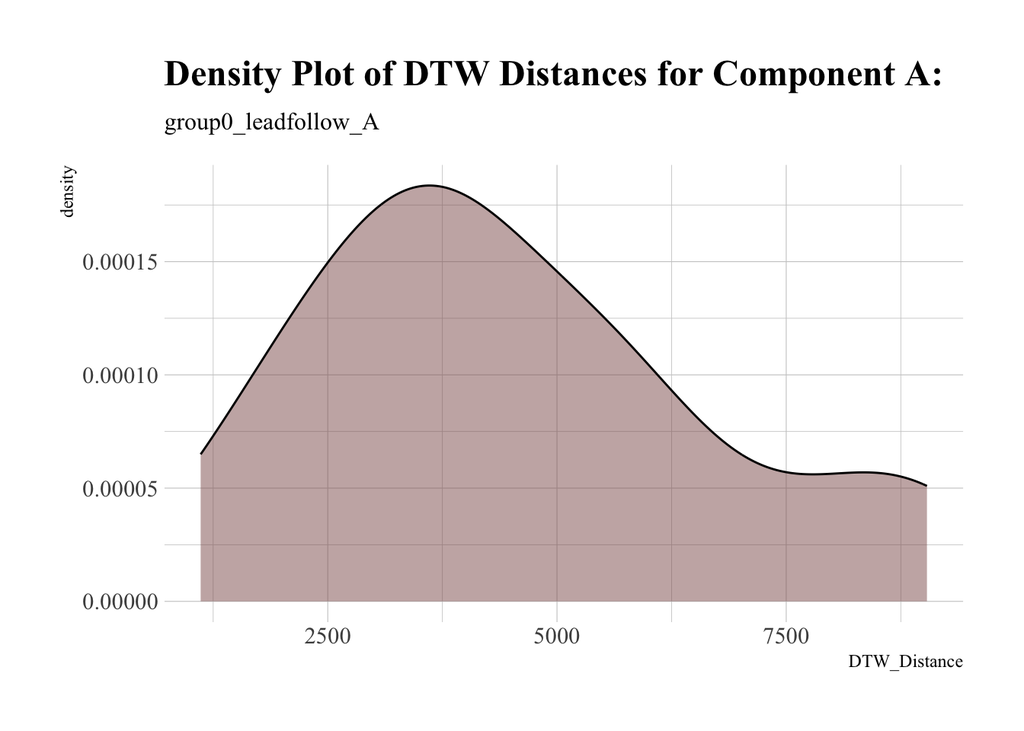

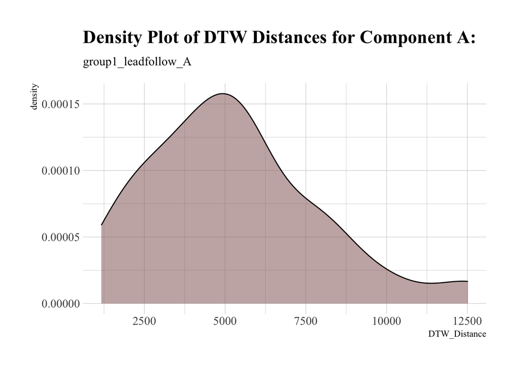

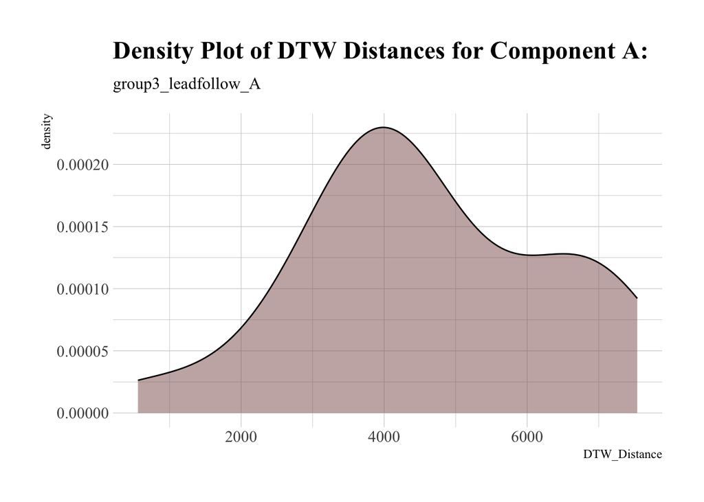

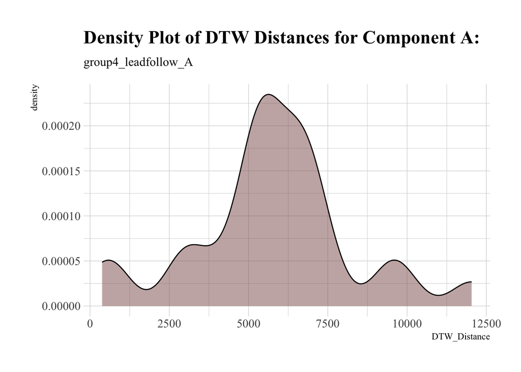

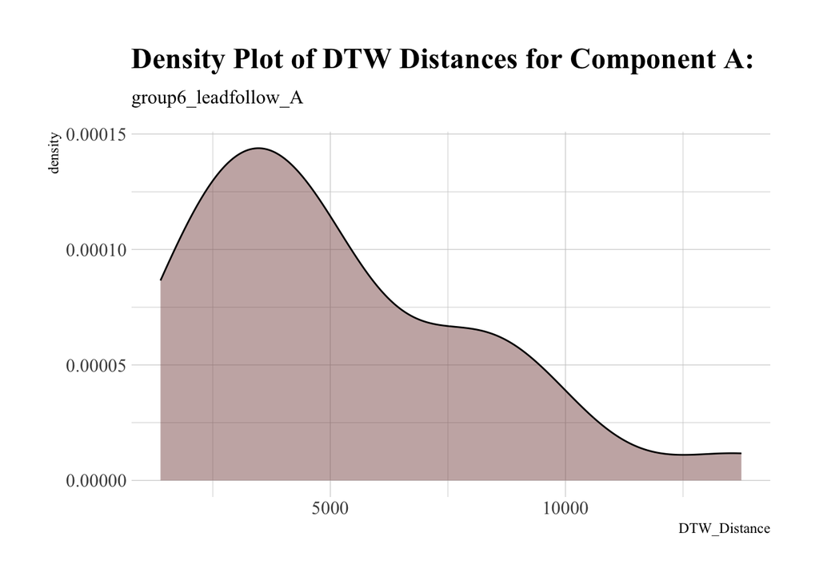

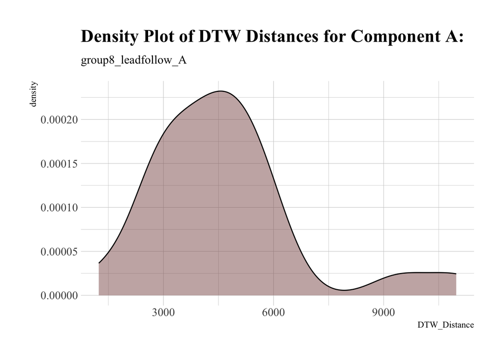

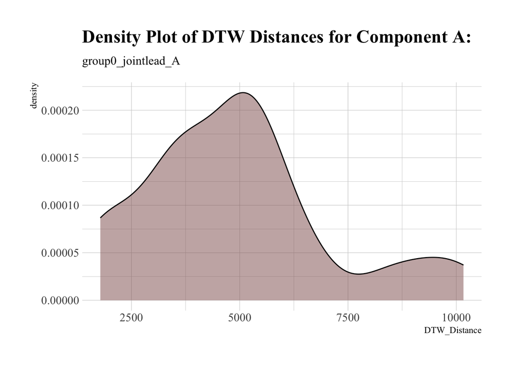

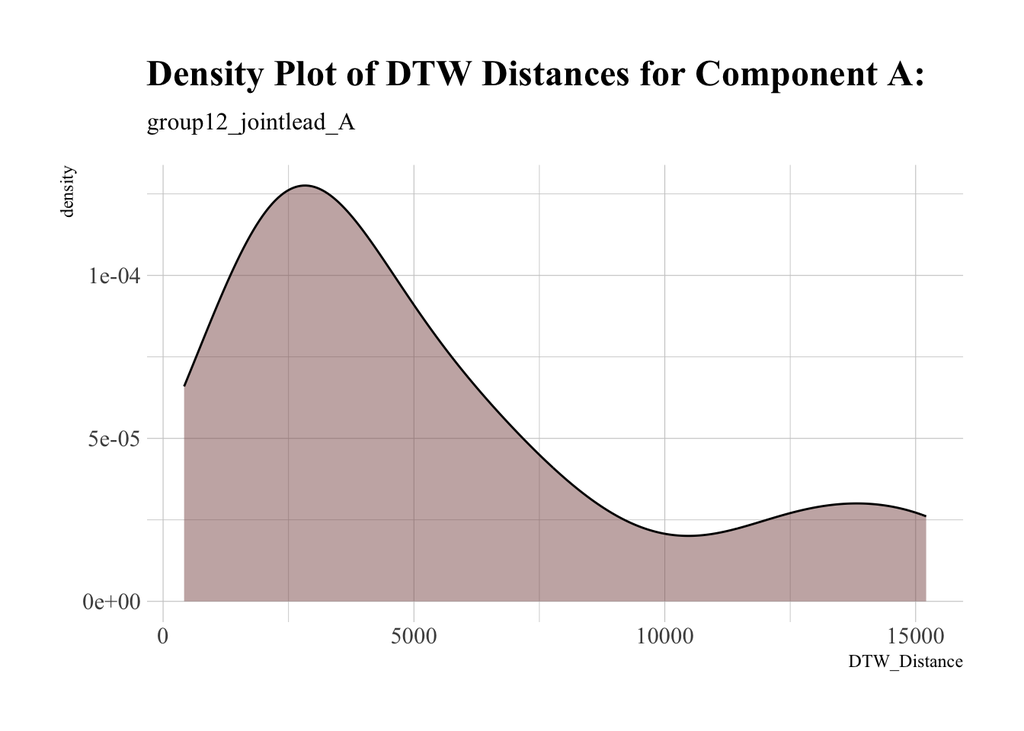

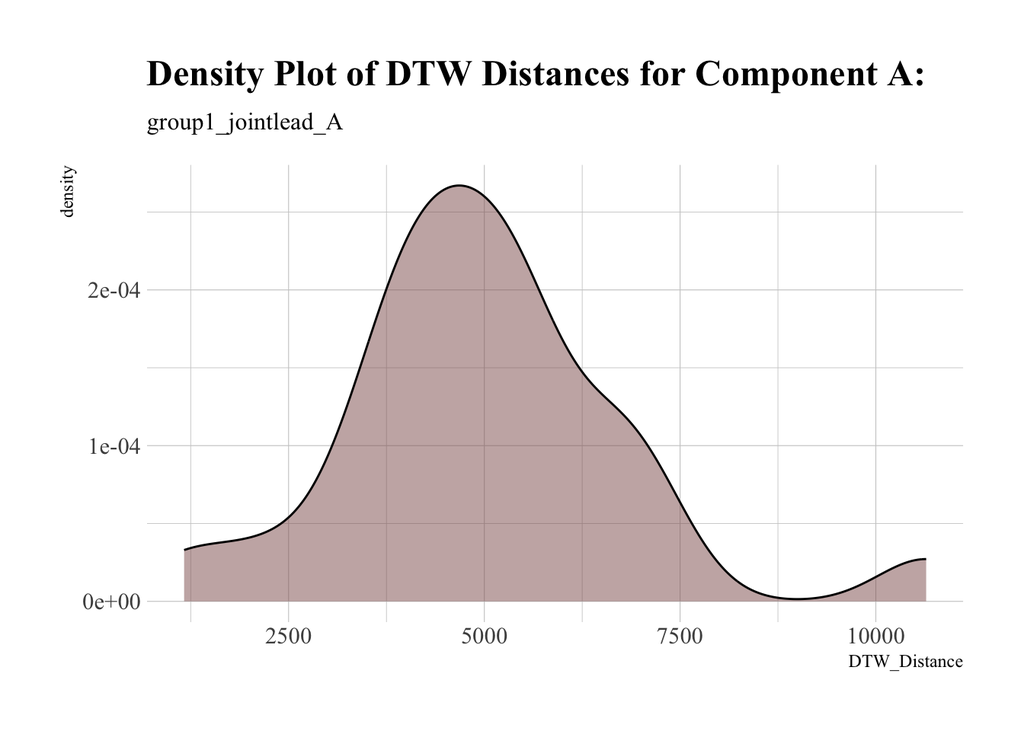

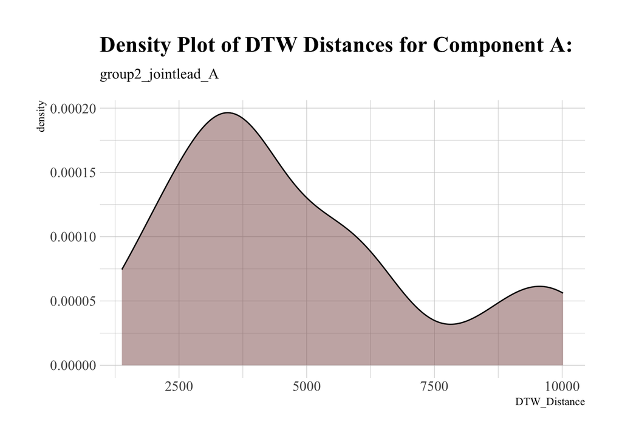

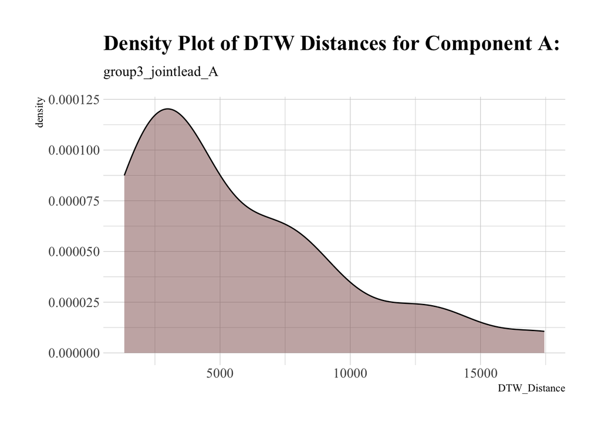

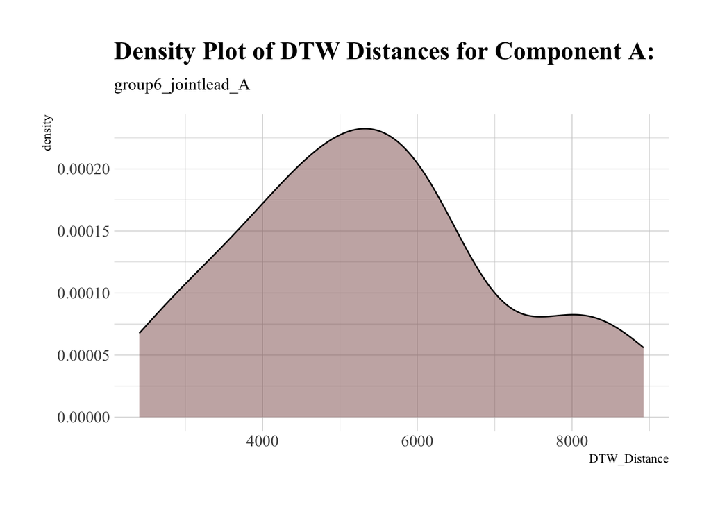

```r
# Loop over each unique value in the 'Component A' column
for (comp_a in unique(false_pairs_df$Component_A)) {
    # Filter the dataframe for the current component
    filtered_df <- subset(false_pairs_df, Component_A == comp_a)

    # Create a density plot
    p <- ggplot(filtered_df, aes(x = DTW_Distance)) +
        geom_density(fill = global_fill_colour, alpha = 0.5) +
      labs(
        title = paste("Density Plot of DTW Distances for Component A:"),
        subtitle = comp_a)

    # Display the plot
    print(p)
}
```

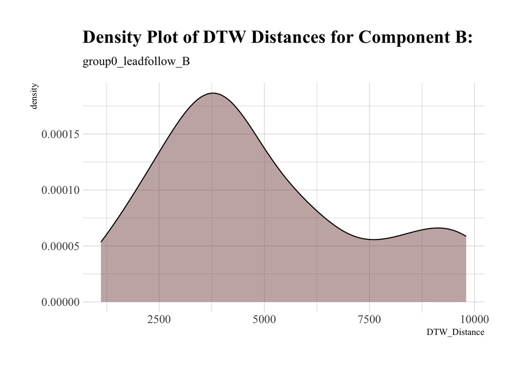

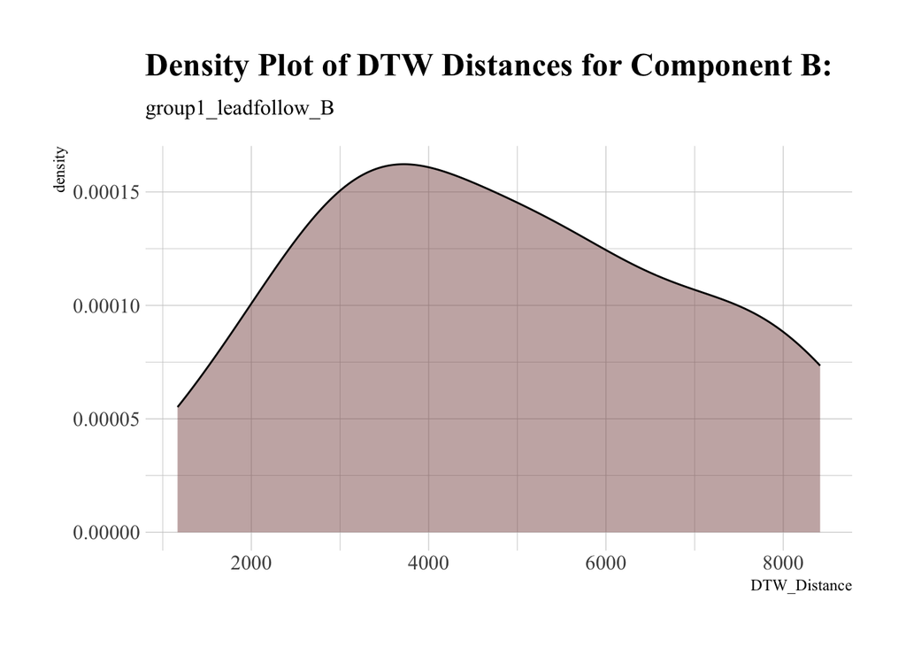

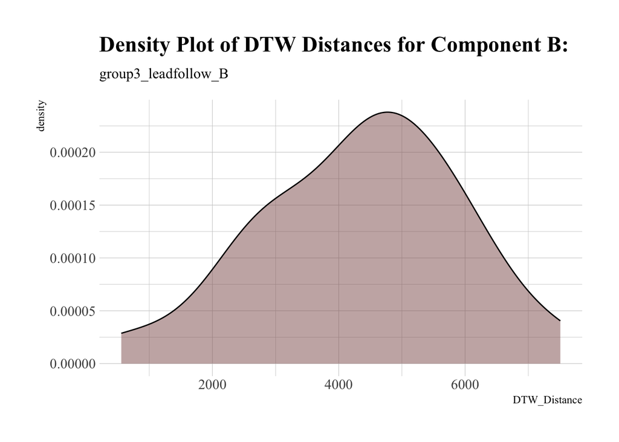

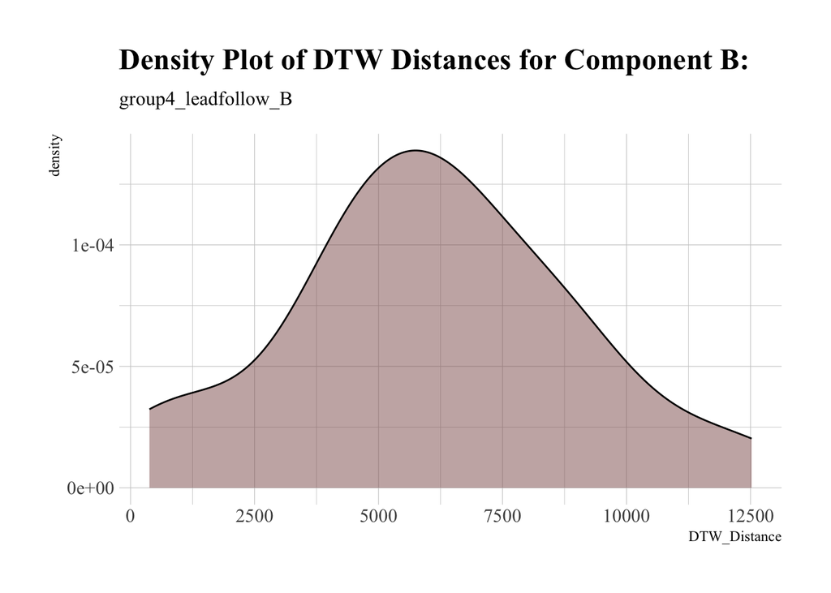

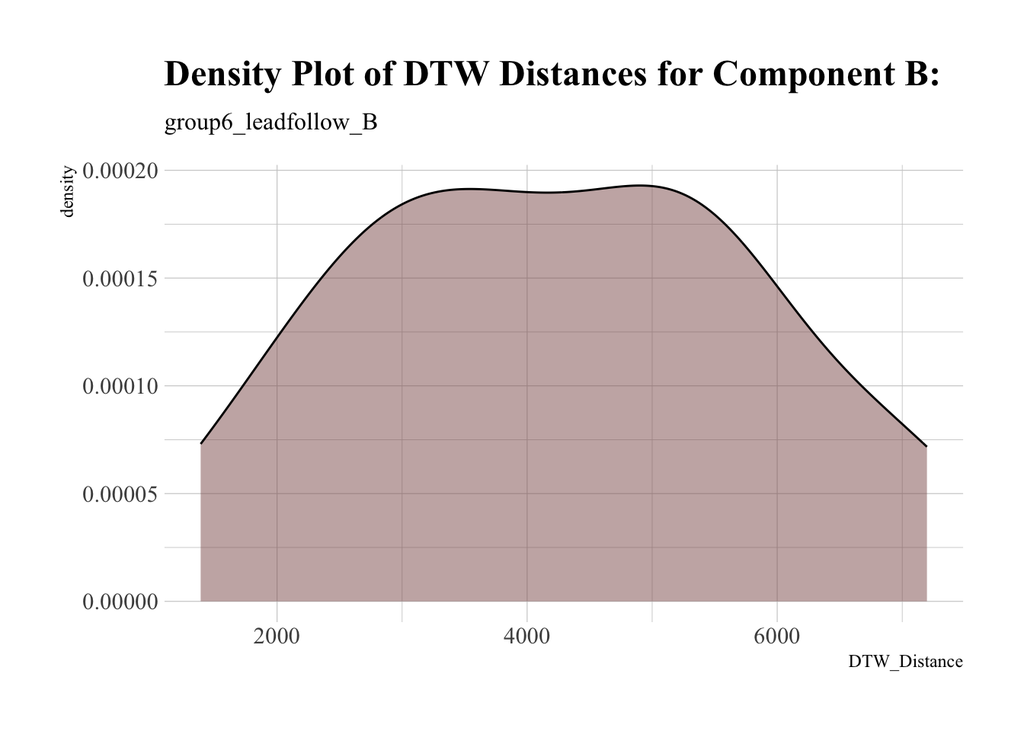

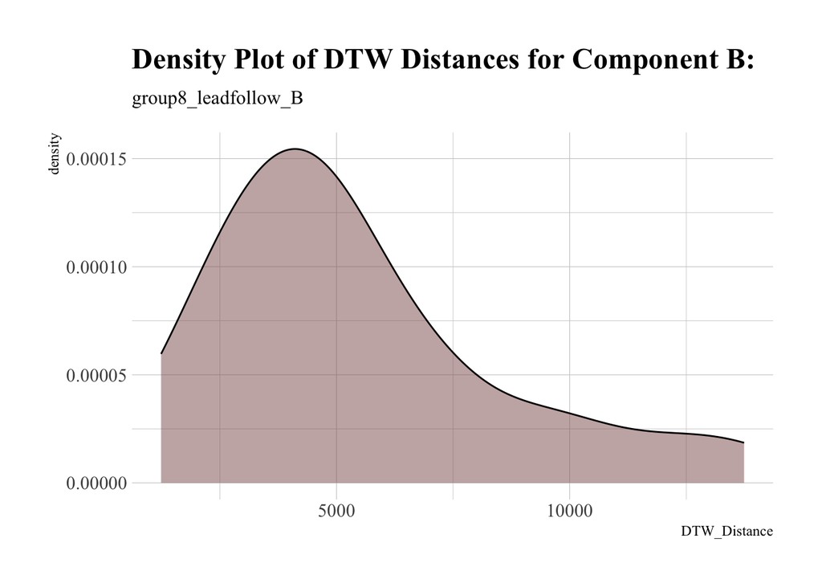

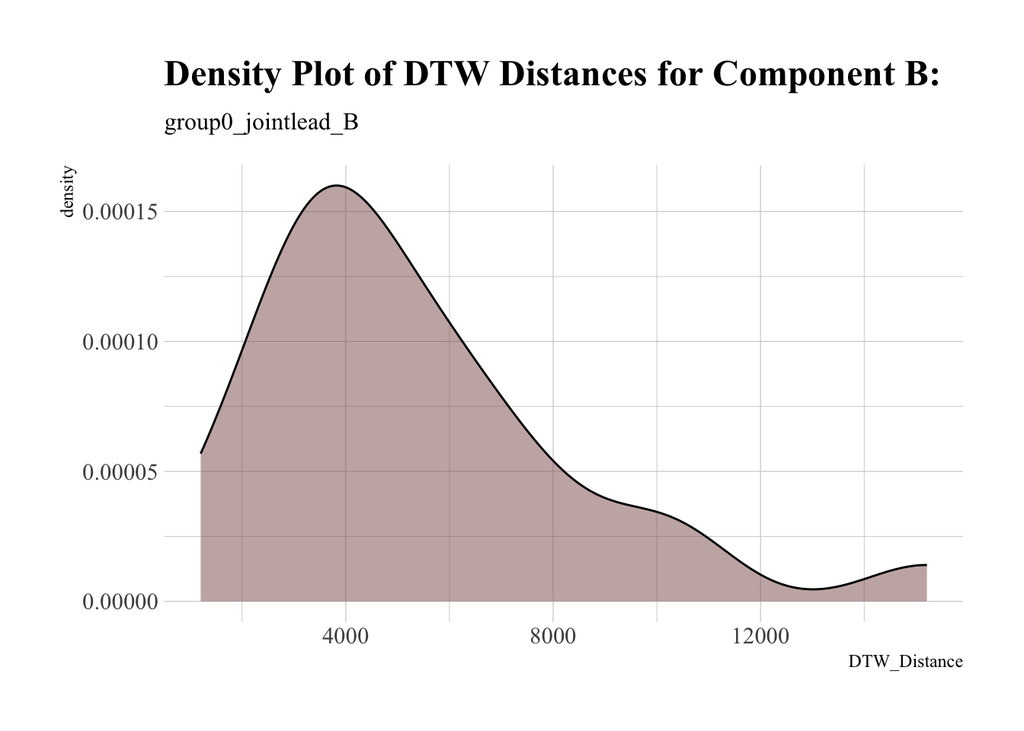

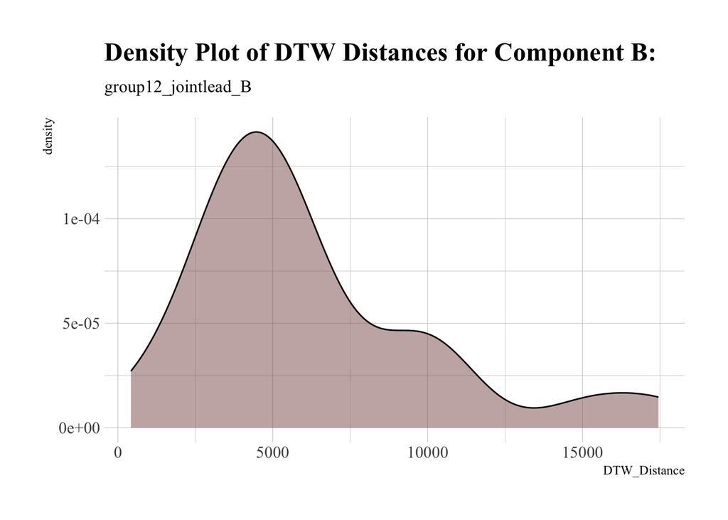

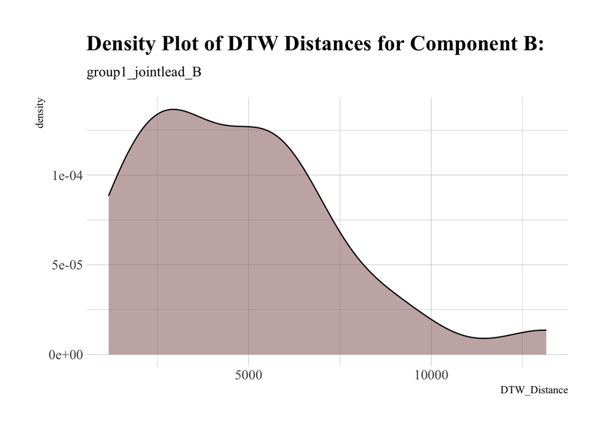

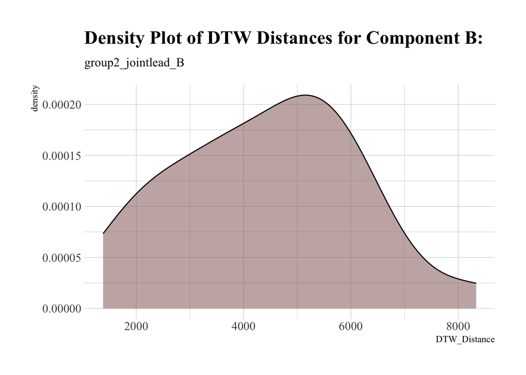

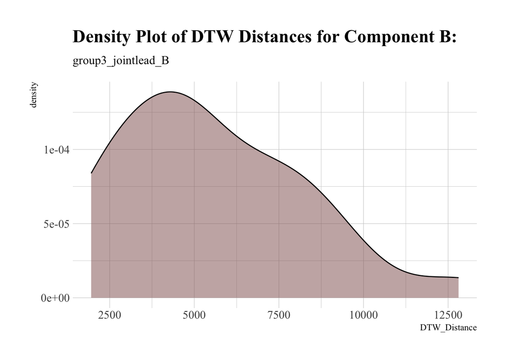

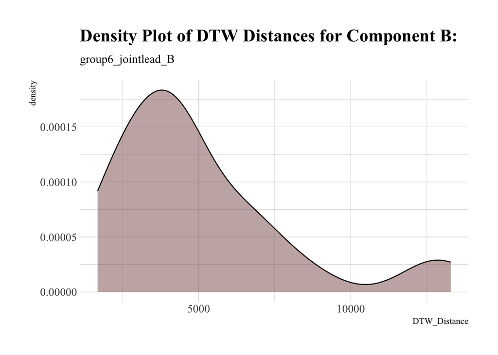

```r
# Loop over each unique value in the 'Component B' column
for (comp_b in unique(false_pairs_df$Component_B)) {
    # Filter the dataframe for the current component
    filtered_df <- subset(false_pairs_df, Component_B == comp_b)

    # Create a density plot
    p <- ggplot(filtered_df, aes(x = DTW_Distance)) +
        geom_density(fill = global_fill_colour, alpha = 0.5) +
      labs(
        title = paste("Density Plot of DTW Distances for Component B:"),
        subtitle = comp_b)

    # Display the plot
    print(p)
}
```

## 1.6 Real pairs

```r
DTW_mean <- mean(dtw_results_df$DTW_Distance)

print(paste("mean:", DTW_mean))
```

```
## [1] "mean: NA"
```

```r
for (i in seq_along(dtw_results_df$DTW_Distance)) {
  dtw_distance <- dtw_results_df$DTW_Distance[i]
  if (dtw_distance <= DTW_mean) {
    group <- dtw_results_df$Group[i]
    condition <- dtw_results_df$Condition[i]
    print(paste("DTW_Distance:", dtw_distance, "Group:", group, "Condition:", condition))
  }
}
```

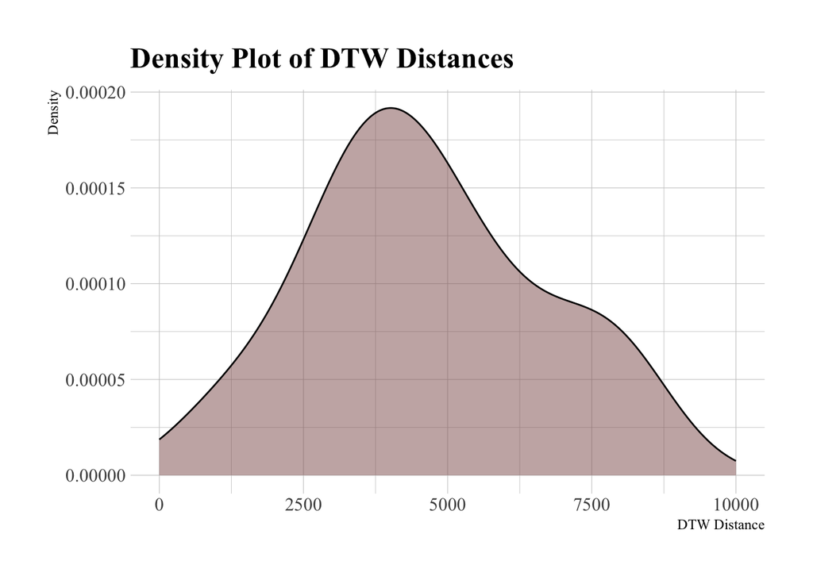

```r
dtw_results_df %>%
  ggplot(aes(x = DTW_Sum)) +
  geom_density(fill = global_fill_colour, alpha = 0.5) +  # Add fill color and adjust transparency
  xlim(0,10000)+
  labs(
    title = "Density Plot of DTW Distances",
    x = "DTW Distance",
    y = "Density"
  )
```

# 2 Exporting the synchrony scores

In order to compare this to each pairs empathy score, we export as a csv to be used in another RMD

```r
write_csv(dtw_results_df, "results/dtw_results_PCA.csv")
write_csv(false_pairs_df, "results/false_pairs_PCA.csv")
```